# 2주차패키지

#문제0번

```r
library(tidyverse)
library(data.table)
library(VIM)
setwd('C:\\Users\\User\\Desktop\\P-SAT\\2주차패키지')
data<-fread("data.csv")
data<-as.data.frame(data)
head(data)
```

```
##     OC bedCount    revenue1 salescost1        sga1     salary1      noi1
## 1 open      175  4217530010          0  3961134739  2033835290  15652441
## 2 open      410          NA         NA          NA          NA      <NA>
## 3 open      468  1004521989  515483669   447219722   296402310     76156
## 4 open      353 72507342181          0 70677397660 31786048663 506223059
## 5 open      196 49043538016          0 47656051197 24460782270 112352259
## 6 open      243 33580536703 9222996930 23727912054 16655333342  65414325
##         noe1  interest1     ctax1   profit1 liquidAsset1 quickAsset1
## 1   15236236   13236236  31641798 225169678   1012699685   997671878
## 2       <NA>       <NA>      <NA>      <NA>         <NA>        <NA>
## 3      30000          0         0  41864754    272442138   253682170
## 4 1259567512 1196881219 173769780 902830288  13041543085 11534749645
## 5 1419089382 1307248652         0  80749696   6317084032  5873265455
## 6  741269419  336462245         0 -46227375   5635104883  5481680248
##   receivableS1 inventoryAsset1  nonCAsset1   tanAsset1 OnonCAsset1 receivableL1
```

[output cut: 34 more lines]

**#CHAPTER1#**  
#문제1번  
’2’로 끝나는 변수를 모두 제거

```r
sdata<-data %>% select(-ends_with("2"))
head(sdata)
```

```
##     OC bedCount    revenue1 salescost1        sga1     salary1      noi1
## 1 open      175  4217530010          0  3961134739  2033835290  15652441
## 2 open      410          NA         NA          NA          NA      <NA>
## 3 open      468  1004521989  515483669   447219722   296402310     76156
## 4 open      353 72507342181          0 70677397660 31786048663 506223059
## 5 open      196 49043538016          0 47656051197 24460782270 112352259
## 6 open      243 33580536703 9222996930 23727912054 16655333342  65414325
##         noe1  interest1     ctax1   profit1 liquidAsset1 quickAsset1
## 1   15236236   13236236  31641798 225169678   1012699685   997671878
## 2       <NA>       <NA>      <NA>      <NA>         <NA>        <NA>
## 3      30000          0         0  41864754    272442138   253682170
## 4 1259567512 1196881219 173769780 902830288  13041543085 11534749645
## 5 1419089382 1307248652         0  80749696   6317084032  5873265455
## 6  741269419  336462245         0 -46227375   5635104883  5481680248
##   receivableS1 inventoryAsset1  nonCAsset1   tanAsset1 OnonCAsset1 receivableL1
## 1    470055740        15027807  2514586477  2360683543   143449600            0
## 2           NA              NA          NA          NA          NA           NA
## 3      8095950        18759968   120481028   120481028           0            0
## 4            0      1506793440 43179356963 38320784344  3945208068            0
## 5   4099320115       443818577 43667333124 43306130668   222340000            0
## 6    663481970       153424635 18649703167 18499383217   136458178            0
##         debt1   surplus1 employee1 ownerChange
## 1   682825991 1496394171        62        same
## 2        <NA>         NA       801        same
## 3    92414342          0       234        same
## 4 42363797762 8643659325       663        same
## 5 49898105519 9025549604       206        same
## 6           0 3664918487       397        same
```

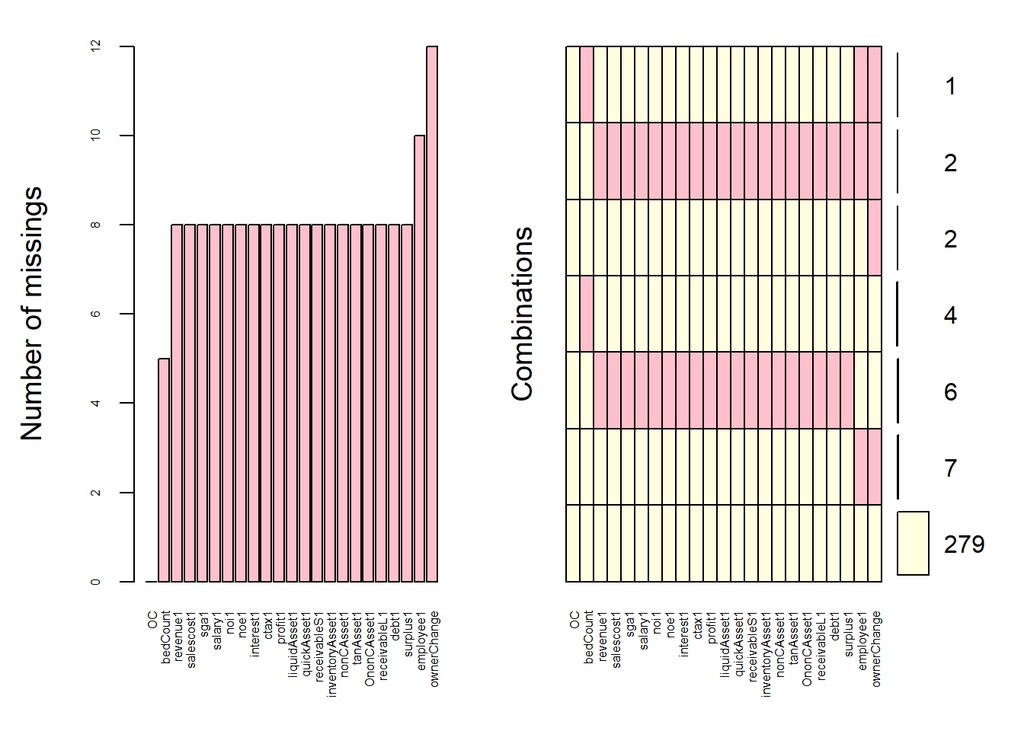

```r
aggr(sdata,col=c('lightyellow','pink'),numbers=TRUE,prop=FALSE,cex.axis=0.5)
```

#문제3-1번  
숫자 데이터의 NA값을 mean imputation을 통해 채우기(lapply 이용)

```r
sdata[]<-lapply(sdata,function(x){
  x[is.na(x)]<-mean(x,na.rm=TRUE)
  x})
head(sdata)
```

```
##     OC bedCount    revenue1 salescost1        sga1     salary1      noi1
## 1 open      175  4217530010          0  3961134739  2033835290  15652441
## 2 open      410 12881747448 2014902795 10332439064  5654114567 269615124
## 3 open      468  1004521989  515483669   447219722   296402310     76156
## 4 open      353 72507342181          0 70677397660 31786048663 506223059
## 5 open      196 49043538016          0 47656051197 24460782270 112352259
## 6 open      243 33580536703 9222996930 23727912054 16655333342  65414325
##         noe1  interest1     ctax1   profit1 liquidAsset1 quickAsset1
## 1   15236236   13236236  31641798 225169678   1012699685   997671878
## 2  511587022  186896557  78473220 210170013   3536586531  3414761591
## 3      30000          0         0  41864754    272442138   253682170
## 4 1259567512 1196881219 173769780 902830288  13041543085 11534749645
## 5 1419089382 1307248652         0  80749696   6317084032  5873265455
## 6  741269419  336462245         0 -46227375   5635104883  5481680248
##   receivableS1 inventoryAsset1  nonCAsset1   tanAsset1 OnonCAsset1 receivableL1
## 1    470055740        15027807  2514586477  2360683543   143449600          0.0
## 2    697586158       115453344 11406727757 10534082118   340650297     251680.2
## 3      8095950        18759968   120481028   120481028           0          0.0
## 4            0      1506793440 43179356963 38320784344  3945208068          0.0
## 5   4099320115       443818577 43667333124 43306130668   222340000          0.0
## 6    663481970       153424635 18649703167 18499383217   136458178          0.0
##         debt1   surplus1 employee1 ownerChange
## 1   682825991 1496394171        62        same
## 2  8765309695 1265934904       801        same
## 3    92414342          0       234        same
## 4 42363797762 8643659325       663        same
## 5 49898105519 9025549604       206        same
## 6           0 3664918487       397        same
```

#문제3-2번  
범주 데이터의 NA값을 mode imputation을 통해 채우기

```r
mode<-!sapply(sdata,is.numeric)
Md<-function(x){
  md1<-sort(unique(x))
  md1[which.max(tabulate(match(x,md1)))]
}
sdata[mode]<-lapply(sdata[mode],function(x) replace(x,is.na(x),Md(x[!is.na(x)])))
```

#문제4번  
변수 ’OC’를 타겟 변수로 바꾸기(open=1,close=0)

```r
sdata$OC<-ifelse(sdata$OC%in%c('open'),1,0)
head(sdata)
```

```
##   OC bedCount    revenue1 salescost1        sga1     salary1      noi1
## 1  1      175  4217530010          0  3961134739  2033835290  15652441
## 2  1      410 12881747448 2014902795 10332439064  5654114567 269615124
## 3  1      468  1004521989  515483669   447219722   296402310     76156
## 4  1      353 72507342181          0 70677397660 31786048663 506223059
## 5  1      196 49043538016          0 47656051197 24460782270 112352259
## 6  1      243 33580536703 9222996930 23727912054 16655333342  65414325
##         noe1  interest1     ctax1   profit1 liquidAsset1 quickAsset1
## 1   15236236   13236236  31641798 225169678   1012699685   997671878
## 2  511587022  186896557  78473220 210170013   3536586531  3414761591
## 3      30000          0         0  41864754    272442138   253682170
## 4 1259567512 1196881219 173769780 902830288  13041543085 11534749645
## 5 1419089382 1307248652         0  80749696   6317084032  5873265455
## 6  741269419  336462245         0 -46227375   5635104883  5481680248
##   receivableS1 inventoryAsset1  nonCAsset1   tanAsset1 OnonCAsset1 receivableL1
## 1    470055740        15027807  2514586477  2360683543   143449600          0.0
## 2    697586158       115453344 11406727757 10534082118   340650297     251680.2
## 3      8095950        18759968   120481028   120481028           0          0.0
## 4            0      1506793440 43179356963 38320784344  3945208068          0.0
## 5   4099320115       443818577 43667333124 43306130668   222340000          0.0
## 6    663481970       153424635 18649703167 18499383217   136458178          0.0
##         debt1   surplus1 employee1 ownerChange
## 1   682825991 1496394171        62        same
## 2  8765309695 1265934904       801        same
## 3    92414342          0       234        same
## 4 42363797762 8643659325       663        same
## 5 49898105519 9025549604       206        same
## 6           0 3664918487       397        same
```

#문제5번  
숫자데이터 integer을 numeric으로 바꾸기(lapply 이용)

```r
sapply(sdata,class)
```

```
##              OC        bedCount        revenue1      salescost1            sga1
##       "numeric"       "numeric"       "numeric"       "numeric"       "numeric"
##         salary1            noi1            noe1       interest1           ctax1
##       "numeric"     "integer64"     "integer64"     "integer64"     "integer64"
##         profit1    liquidAsset1     quickAsset1    receivableS1 inventoryAsset1
##     "integer64"     "integer64"     "integer64"       "numeric"       "numeric"
##      nonCAsset1       tanAsset1     OnonCAsset1    receivableL1           debt1
##       "numeric"       "numeric"       "numeric"       "numeric"     "integer64"
##        surplus1       employee1     ownerChange
##       "numeric"       "numeric"     "character"
```

```r
sdata[]<-lapply(sdata,function(x){
  if(bit64::is.integer64(x)){
    as.numeric(x)}
  else x})
sapply(sdata,class)
```

```
##              OC        bedCount        revenue1      salescost1            sga1
##       "numeric"       "numeric"       "numeric"       "numeric"       "numeric"
##         salary1            noi1            noe1       interest1           ctax1
##       "numeric"       "numeric"       "numeric"       "numeric"       "numeric"
##         profit1    liquidAsset1     quickAsset1    receivableS1 inventoryAsset1
##       "numeric"       "numeric"       "numeric"       "numeric"       "numeric"
##      nonCAsset1       tanAsset1     OnonCAsset1    receivableL1           debt1
##       "numeric"       "numeric"       "numeric"       "numeric"       "numeric"
##        surplus1       employee1     ownerChange
##       "numeric"       "numeric"     "character"
```

**#CHAPTER2#**  
[모델1로지스틱 회귀]  
#문제1번  
createDatePartition을 이용하여 train과 validation set을 7:3으로 나누기

```r
library(caret)
library(MLmetrics)
library(randomForest)
set.seed(1234)
inTrain<-createDataPartition(y=sdata$OC,p=0.3,list=FALSE)
training<-sdata[-inTrain,]
validationset<-sdata[inTrain,]
nrow(training)
```

```
## [1] 210
```

```r
nrow(validationset)
```

```
## [1] 91
```

#문제2번  
’OC’를 타겟으로 로지스틱 회귀를 만들고 validation set의 Accuracy값을 구함

```r
logit_model1<-glm(OC~.,family='binomial',data=training)
pred0<-predict(logit_model1,newdata=validationset,type='response')
pred1<-ifelse(pred0<0.5,0,1)
Accuracy(y_pred=pred1,y_true=validationset$OC)
```

```
## [1] 0.9120879
```

#문제3번  
단계적선택법을 이용하여 변수를 선택하고 validation set의 Accuracy를 구함

```r
step(glm(OC~.,family=binomial,data=training),scope=list(lower=~1,upper=~.),direction='both')
```

```
## Start:  AIC=74.95
## OC ~ bedCount + revenue1 + salescost1 + sga1 + salary1 + noi1 +
##     noe1 + interest1 + ctax1 + profit1 + liquidAsset1 + quickAsset1 +
##     receivableS1 + inventoryAsset1 + nonCAsset1 + tanAsset1 +
##     OnonCAsset1 + receivableL1 + debt1 + surplus1 + employee1 +
##     ownerChange
##
##                   Df Deviance    AIC
## - ctax1            1   28.953 72.953
## - salescost1       1   28.953 72.953
## - revenue1         1   28.953 72.953
## - sga1             1   28.953 72.953
## - profit1          1   28.953 72.953
## - noi1             1   28.953 72.953
## - noe1             1   28.953 72.953
## - debt1            1   28.956 72.956
## - surplus1         1   28.993 72.993
## - employee1        1   29.027 73.027
## - OnonCAsset1      1   29.059 73.059
## - bedCount         1   29.280 73.280
## - salary1          1   29.482 73.482
## - liquidAsset1     1   29.696 73.696
## - quickAsset1      1   29.779 73.779
## - inventoryAsset1  1   30.373 74.373
## - tanAsset1        1   30.777 74.777
## - nonCAsset1       1   30.791 74.791
## - interest1        1   30.834 74.834
## - receivableL1     1   30.848 74.848
## <none>                 28.953 74.953
## - ownerChange      1   31.231 75.231
## - receivableS1     1   32.724 76.724
##
## Step:  AIC=72.95
## OC ~ bedCount + revenue1 + salescost1 + sga1 + salary1 + noi1 +
##     noe1 + interest1 + profit1 + liquidAsset1 + quickAsset1 +
##     receivableS1 + inventoryAsset1 + nonCAsset1 + tanAsset1 +
##     OnonCAsset1 + receivableL1 + debt1 + surplus1 + employee1 +
##     ownerChange
##
##                   Df Deviance    AIC
```

[output cut: 341 more lines]

```
## + inventoryAsset1  1   33.288 57.288
## + noe1             1   33.503 57.503
## + liquidAsset1     1   33.639 57.639
## + surplus1         1   33.648 57.648
## + salary1          1   33.730 57.730
## + ctax1            1   33.750 57.750
## + OnonCAsset1      1   33.778 57.778
## - noi1             1   37.849 57.849
## - receivableS1     1   41.989 61.989
## - salescost1       1   43.897 63.897
## - tanAsset1        1   44.764 64.764
## - nonCAsset1       1   44.912 64.912
## - receivableL1     1   45.647 65.647
## - quickAsset1      1   46.898 66.898
## - revenue1         1   47.877 67.877
```

```
##
## Call:  glm(formula = OC ~ revenue1 + salescost1 + noi1 + interest1 +
##     quickAsset1 + receivableS1 + nonCAsset1 + tanAsset1 + receivableL1 +
##     ownerChange, family = binomial, data = training)
##
## Coefficients:
##     (Intercept)         revenue1       salescost1             noi1
##       2.162e+00        6.986e-10       -1.151e-09       -2.777e-09
##       interest1      quickAsset1     receivableS1       nonCAsset1
##      -5.214e-09       -1.034e-09       -1.456e-09        1.662e-08
##       tanAsset1     receivableL1  ownerChangesame
##      -1.658e-08       -1.888e-06        2.167e+00
##
## Degrees of Freedom: 209 Total (i.e. Null);  199 Residual
## Null Deviance:       74.31
## Residual Deviance: 33.78     AIC: 55.78
```

```r
logit_model2<-glm(OC~revenue1+salescost1+noi1
                  +interest1+quickAsset1+receivableS1
                  +nonCAsset1+tanAsset1+receivableL1,
                  family=binomial,data=training)
pred2<-predict(logit_model2,newdata=validationset,type='response')
pred3<-ifelse(pred2<0.5,0,1)
Accuracy(y_pred=pred3,y_true=validationset$OC)
```

```
## [1] 0.9340659
```

[모델2 랜덤포레스트]  
#문제4번  
expand.grid를 이용하여 데이터 프레임 작성

```r
mtry_grid<-3:5
acc_rf<-expand.grid("mtry"=mtry_grid)
acc_rf$acc<-rep(NA,nrow(acc_rf))
acc_rf
```

```
##   mtry acc
## 1    3  NA
## 2    4  NA
## 3    5  NA
```

```r
set.seed(1234)
cv_index<-createFolds(sdata$OC,k=5,list=TRUE)
mtry_grid<-3:5
x=1
for(i in 1:length(mtry_grid)){
  for(k in 1:5){
    cv_train=sdata[-cv_index[[k]],]
    cv_test=sdata[cv_index[[k]],]
    set.seed(1234)
    cv_acc<-c()
    rf<-randomForest(OC~ revenue1+salescost1+sga1+noi1+noe1+interest1+
                       profit1+liquidAsset1+quickAsset1+receivableS1+
                       inventoryAsset1+nonCAsset1+tanAsset1+surplus1+
                       ownerChange, data = cv_train, mtry = mtry_grid[i],
                     ntree = 10, importance = F)
    data.pred = predict(rf, newdata = cv_test, type = 'response')
    rf.pred<-ifelse(data.pred < 0.5, 0, 1)
    rf.acc<- sum(rf.pred) / length(rf.pred)
    cv_acc = rf.acc
  }
  acc_rf[x, "acc"] = max(cv_acc)
  x = x + 1
}
```

[output not shown]

```r
acc_rf
```

```
##   mtry       acc
## 1    3 0.9833333
## 2    4 1.0000000
## 3    5 0.9833333
```

#문제6번  
acc_rf에서 가장 높은 Accuracy값의 행을 출력

```r
acc_rf[which.max(acc_rf$acc),]
```

```
##   mtry acc
## 2    4   1
```

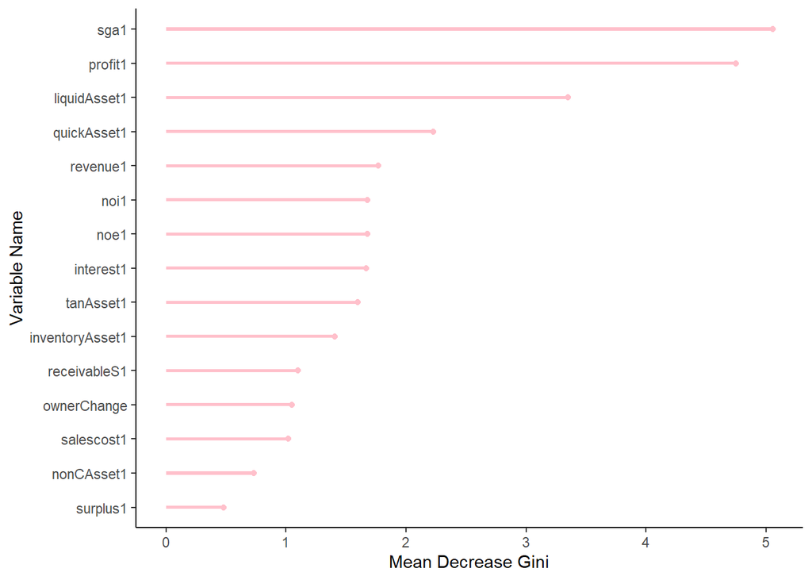

```r
set.seed(1234)
Rf=randomForest(as.factor(OC)~revenue1+salescost1+sga1+noi1+noe1+interest1+
                  profit1+liquidAsset1+quickAsset1+receivableS1+
                  inventoryAsset1+nonCAsset1+tanAsset1+surplus1+
                  ownerChange, cv_train, mtry=4, ntree=10,importance=T)
im<-importance(Rf)
im.Rf<-im[,c(3,4)]
im.Rf<-as.matrix(im.Rf)
im.Rf<-data.frame(variable=rownames(im.Rf),im.Rf)
rownames(im.Rf)<-c(1:15)
imRfsort<-transform(im.Rf, variable=reorder(variable,MeanDecreaseGini))
ggplot(data=imRfsort, aes(x=variable,y=MeanDecreaseGini))+
  theme_classic()+geom_bar(stat='identity',fill='pink', width=0.09)+
  geom_point(color='pink',size=1.5)+coord_flip()+
  ylab("Mean Decrease Gini")+xlab("Variable Name")
```

**#CHAPTER3#**  
#문제1번  
Boston 데이터를 8:2로 train과 test set으로 나눔

```r
library(MASS)
library(caret)
library(MLmetrics)
library(randomForest)
Boston<-as.data.frame(Boston)
head(Boston)
```

```
##      crim zn indus chas   nox    rm  age    dis rad tax ptratio  black lstat
## 1 0.00632 18  2.31    0 0.538 6.575 65.2 4.0900   1 296    15.3 396.90  4.98
## 2 0.02731  0  7.07    0 0.469 6.421 78.9 4.9671   2 242    17.8 396.90  9.14
## 3 0.02729  0  7.07    0 0.469 7.185 61.1 4.9671   2 242    17.8 392.83  4.03
## 4 0.03237  0  2.18    0 0.458 6.998 45.8 6.0622   3 222    18.7 394.63  2.94
## 5 0.06905  0  2.18    0 0.458 7.147 54.2 6.0622   3 222    18.7 396.90  5.33
## 6 0.02985  0  2.18    0 0.458 6.430 58.7 6.0622   3 222    18.7 394.12  5.21
##   medv
## 1 24.0
## 2 21.6
## 3 34.7
## 4 33.4
## 5 36.2
## 6 28.7
```

```r
set.seed(1234)
index_Train<-createDataPartition(Boston$medv,p=0.2,list=F)
train <- Boston[-index_Train, ]
test <- Boston[index_Train, ]
nrow(train)
```

```
## [1] 403
```

```r
nrow(test)
```

```
## [1] 103
```

#문제2번  
expand.grid를 이용하여 다음과 같은 데이터 프레임 작성

```r
mtry_grid<-3:5
ntree_grid <- rep(c(10,100,200))
RMSE_rf<-expand.grid("mtry"=mtry_grid,"ntree"=ntree_grid)
RMSE_rf$RMSE=rep(NA,nrow(RMSE_rf))
RMSE_rf
```

```
##   mtry ntree RMSE
## 1    3    10   NA
## 2    4    10   NA
## 3    5    10   NA
## 4    3   100   NA
## 5    4   100   NA
## 6    5   100   NA
## 7    3   200   NA
## 8    4   200   NA
## 9    5   200   NA
```

#문제3번  
medv를 종속변수로 하는 랜덤포레스트에 대한 5-fold CV 그리드서치를 진행하여 RMSE_rf의 RMSE 변수에 해당 RMSE값을 넣음

```r
set.seed(1234)
cv_index2<-createFolds(train$medv,k=5,list=T)
for(i in 1: nrow(RMSE_rf)){
  cv_rmse=NULL
  for(k in 1:5){
    cv_train = train[-cv_index2[[k]],]
    cv_test = train[cv_index2[[k]],]
    rf = randomForest(medv~.,
                      data = cv_train,
                      mtry=RMSE_rf[i,1],
                      num.trees=RMSE_rf[i,2],
                      importance = F)
    temp_pred = predict(rf, newdata=cv_test[-14],type='response')
    temp_RMSE = RMSE(temp_pred, cv_test$medv)
    cv_rmse = c(cv_rmse, temp_RMSE)
  }
  RMSE_rf[i, "RMSE"] = mean(cv_rmse)
}
RMSE_rf
```

```
##   mtry ntree     RMSE
## 1    3    10 3.568651
## 2    4    10 3.555021
## 3    5    10 3.495864
## 4    3   100 3.550335
## 5    4   100 3.520072
## 6    5   100 3.485574
## 7    3   200 3.535886
## 8    4   200 3.521762
## 9    5   200 3.497149
```

```r
RMSE_rf = RMSE_rf %>%
  arrange(RMSE)

opt_param = RMSE_rf[1,]
opt_param
```

```
##   mtry ntree     RMSE
## 1    5   100 3.485574
```

#문제5번 train set으로 그리드 서치로 나온 가장 좋은 조합의 파라미터의 랜덤포레스트를 학습시킨 후, test set의 RMSE를 구하세요

```r
set.seed(1234)
rf_model = randomForest(medv ~ ., data = train,
                        mtry = opt_param$mtry, ntree = opt_param$ntree)

rf_yhat = predict(rf_model,test)

RMSE(rf_yhat,test$medv)
```

```
## [1] 4.128906
```